# Evolution of international research collaborative efforts to develop non-Cochrane systematic reviews

Datasets and scripts were used for PROSPERO records and SR’s protocols analyses are integrated in this [R Markdown](http://rmarkdown.rstudio.com) Notebook. When you execute code within the notebook, the results appear beneath the code.

These dataset and R scripts WERE created by Juan Ruano and co-authored by I. Viguera-Guerra(a,1), J. Ruano(b,c,1,∗), M. Aguilar-Luque(b), J. Gay-Mimbrera(b), A. Montilla(b,e), J. L.Fernández-Rueda(b), J. Fernández-Chaichio(b), J.L. Sanz-Cabanillas(b,c), P. Gómez-Arias(b,c), A. Vélez García-Nieto(b,c), F. Gómez-García(b,c), B. Isla-Tejera(b,d). a Agencia de Evaluación de Tecnologías Sanitarias de Andalucía (AETSA), 14004 Sevilla, Spain b IMIBIC/Reina Sofía University Hospital/University of Cordoba, 14004 Córdoba, Spain c Department of Dermatology, Reina Sofía University Hospital, 14004 Córdoba, Spain d Department of Pharmacy, Reina Sofía University Hospital, 14004 Córdoba, Spain e School of Medicine, University of Cordoba, 14004 Córdoba, Spain.

They are of freely use (MIT License).

1 Equal contributors

Corresponding author: juanruanoruiz@mac.com

# 0. Packages, functions, and datasets.

# Basic statistics.

```r
#### 2': number or reviewers->total and per protocol
####
new_data$number_of_authors_PC <- stringr::str_count(new_data$publication_authors, ";")+1
new_data %>%
  group_by(group) %>%
  summarise(
    median=median(number_of_authors_PC),
    min=min(number_of_authors_PC),
    max=max(number_of_authors_PC)
  )
```

```
## # A tibble: 3 x 4
##   group                median   min   max
##   <fct>                 <dbl> <dbl> <dbl>
## 1 Only_Journal              5     1    57
## 2 Only_PROSPERO            NA    NA    NA
## 3 PROSPERO_and_Journal      5     2    41
```

```r
###### number of countries: total and per protocol
new_data$publication_countries_count <- str_count(new_data$ALL_country_curated, ",")+1
sum(na.omit(new_data$publication_countries_count))
```

```
## [1] 25095
```

```r
new_data %>% group_by(group) %>%
  summarise(
    median=median(publication_countries_count, na.rm=TRUE),
    min=min(publication_countries_count, na.rm=TRUE),
    max=max(publication_countries_count, na.rm=TRUE)
  )
```

```
## # A tibble: 3 x 4
##   group                median   min   max
##   <fct>                 <dbl> <dbl> <dbl>
## 1 Only_Journal              1     1    14
## 2 Only_PROSPERO             1     1   159
## 3 PROSPERO_and_Journal      1     1     7
```

```r
more<-subset(new_data, publication_countries_count>1)
unique<-subset(new_data, publication_countries_count<2)

dim(more)
```

```
## [1] 1896   42
```

```r
dim(unique)
```

```
## [1] 17277    42
```

# Figure 1.

1. Frequency of protocols published from 2011 to 2017 comparing those protocols published ‘only in a journal’, ‘only at PROSPERO’, and in both ‘journal and PROSPERO’.

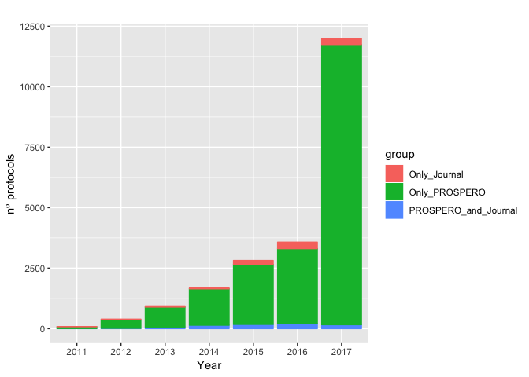

```r
### 1: plot protocols BY year x  group
ggplot(new_data,aes(x=ALL_year, group=group, fill=group, color=group)) +
geom_bar () +
xlab("Year") +
ylab("nº protocols")+
ggtitle(" ")
```

3. Map representation of number of protocols produced by country (as proxy of reviewer’s affiliation country). Colours represent levels of productivity defined by quartiles of a new recoded variable [abs(log2(country.count/all.countries.count))] (red, very high; yellow, high; green, medium; blue, low).

```r
library(rworldmap)
data_map                            <- as.data.frame(read.csv2(file="unique_countries_count_resumed.csv", sep=" "))
cutVector                           <- quantile(data_map$count,na.rm=TRUE)
data_map$country_categories         <- cut(data_map$count, cutVector, include.lowest=TRUE )
levels(data_map$country_categories) <- c("low", "med", "high", "vhigh")
n                                   <- joinCountryData2Map(data_map, joinCode="NAME", nameJoinColumn="country")
```

```
## 121 codes from your data successfully matched countries in the map
## 3 codes from your data failed to match with a country code in the map
## 122 codes from the map weren't represented in your data
```

```
## using catMethod='categorical' for non numeric data in mapCountryData
```

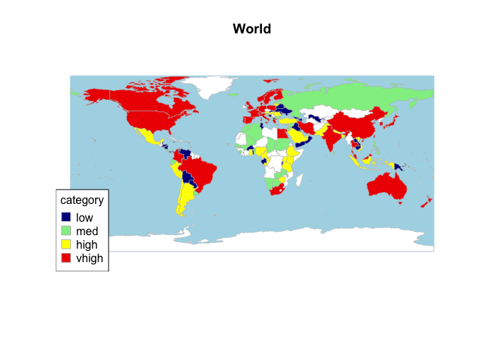

```r
mapCountryData(n, nameColumnToPlot="country_categories", mapTitle="World",addLegend = TRUE, oceanCol="lightblue", colourPalette="diverging", missingCountryCol="white")
```

4. World cloud of ‘unique countries’. Text size and centering is proportional to the associated number of protocols. Colours have been randomly assigned.

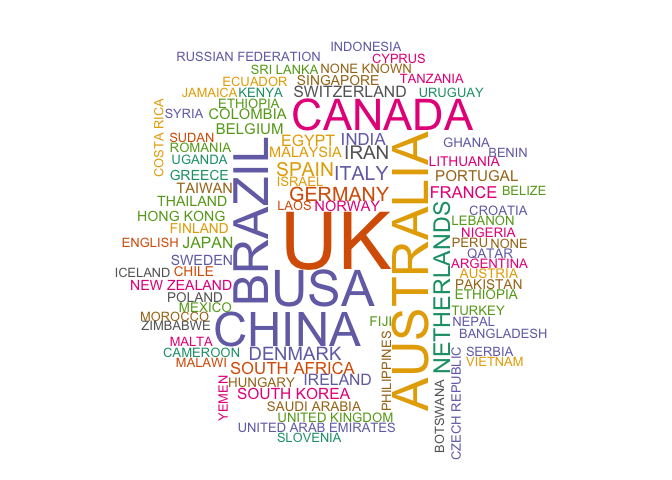

```r
set.seed(1234)
unique_countries                     <- new_data %>%
  filter(!str_detect(ALL_country_curated, ','))
unique_countries_all                 <- unique_countries %>%
  filter(!str_detect(ALL_country_curated, '\t'))

table_all_unique_countries           <- as.data.frame(table(unique_countries_all[,c(16)]))
table_country                        <- subset(table_all_unique_countries, Freq>1)
wordcloud(table_country$Var1, table_country$Freq/min(table_country$Freq)+1, max.words = 300, min.freq = 1,
          random.order=FALSE, scale = c(5, 0.8), colors=brewer.pal(8,"Dark2"), random.color=TRUE)
```

5. World cloud of ‘collaborative countries’. Text size and centering is proportional to the associated number of protocols. Colours have been randomly assigned.

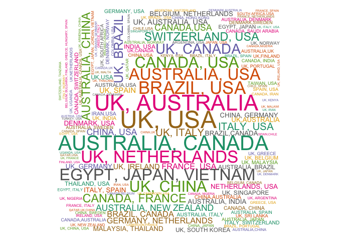

```r
set.seed(1234)
collaborative_countries              <-new_data %>%
  filter(str_detect(ALL_country_curated, ','))
table_all_collaborative_countries <- as.data.frame(table(collaborative_countries[,c(16)]))

table_all_collaborative_countries_uk <-table_all_collaborative_countries %>%
  filter(!str_detect(Var1, "UK, UK|UK, UK, UK|UK, UK, UK, UK|POLAND"))

table_country                        <- subset(table_all_collaborative_countries_uk, Freq>1)
set.seed(1234)
wordcloud(table_country$Var1, table_country$Freq/min(table_country$Freq), max.words = 300, min.freq = 1, scale = c(3, 0.2),
          random.order=FALSE, colors=brewer.pal(8,"Dark2"), random.color=TRUE)
```

6. World cloud of ‘scientific journals’. Text size and centering is proportional to the associated number of protocols. Colours have been randomly assigned.

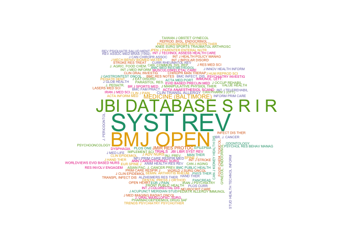

```r
set.seed(1234)
new_data<-read.csv("protocol_dataset_curated_17JUN2018.csv", sep=";")
new_data<-subset(new_data, ALL_year>2010 & ALL_year<2019)
new_data$ALL_year<-factor(new_data$ALL_year)
new_data_journal<-subset(new_data, group=="Only_Journal" | group=="PROSPERO_and_Journal")
table_journal <- as.data.frame(table(new_data_journal[,c(11)]))
levels(table_journal$Var1)[levels(table_journal$Var1)=="JBI DATABASE SYSTEM REV IMPLEMENT REP" ] <- "JBI DATABASE S R I R"
table_journal<-subset(table_journal, Freq>0)
wordcloud(table_journal$Var1, table_journal$Freq/min(table_journal$Freq)+1, max.words = 120, min.freq = 0,
          random.order=FALSE, scale = c(3, 0.4),colors=brewer.pal(6,"Dark2"), random.color=TRUE)
```

7. Column plots of ocurrences of ‘unique countries’ ranked by total number of protocols.